# Routine pharmacovigilance

```r
library(vigicaen)
```

# Motivation

The aim of this vignette is to describe how to use vigicaen in the context of routine pharmacovigilance.

In a hurry? Check the condensed script of this vignette at `vignette("template_routine")`.

The standard user of this vignette is:

- A pharmacovigilance practitioner
- Interested in R, but not necessarily willing to become an R expert, nor a data management expert.
- Working on a pharmacovigilance case, and seeking for additional data, to improve his/her case report: Disproportionality Estimates, possibly refined to a certain context, and time from drug initiation to reaction onset.

Meeting these criteria? Then this vignette is for you!

# The whole game

The idea is to reduce to the minimum steps to get data from VigiBase.

1. Load VigiBase data into R
2. Identify the drug and reaction of interest
3. Run `vigi_routine()`
4. Save the results, in order to insert them into your pharmacovigilance report.

`vigi_routine()` is intended as the cornerstone function in this workflow.

> We will use the following example: Say a physician reported a case of colitis with ipilimumab. We would like to know if there is a reporting association between colitis and ipilimumab, and we would like to analyze time to onset.

Obviously, the first part is more interesting if the association between colitis and ipilimumab is not well established.

# Load tables

If you haven’t already, you should build tables in an R compatible format, using the `tb_vigibase()` and `tb_who()` functions. More information can be found in `vignette("getting_started")`.

This rather long step must only be done once per database version.

Then, you need to set up the paths to your tables, and use `dt_parquet()`.

```r
path_base   <- "~/vigibase/main/"
path_who    <- "~/vigibase/who/"
path_meddra <- "~/meddra/"
```

Load tables into R. Preferably, let them out of memory, especially if you have a computer with rather low specifications (e.g., 16GB of RAM).

```r
demo <- dt_parquet(path_base, "demo", in_memory = FALSE)
drug <- dt_parquet(path_base, "drug", in_memory = FALSE)
adr  <- dt_parquet(path_base, "adr", in_memory = FALSE)
link <- dt_parquet(path_base, "link", in_memory = FALSE)

mp     <- dt_parquet(path_who,    "mp")
meddra <- dt_parquet(path_meddra, "meddra_hierarchy")
```

For this vignette, we will use built-in example tables instead.

```r
demo     <- demo_
adr      <- adr_
drug     <- drug_
link     <- link_

mp <- mp_
meddra   <- meddra_
```

# Identify drug and reaction of interest

## Select the drug and reaction

First, create named lists of the drug and reaction of interest. This is exactly similar to the `vignette("basic_workflow")`.

```r
d_sel <- list(
  ipilimumab = "ipilimumab"
)

a_sel <- list(
  # this is a High Level Term
  colitis = "Colitis (excl infective)"
)
```

When working with vigicaen, we always need to tell R which drug and which reaction we are interested in. Here, we create the `d_sel` object, which is a list, with one item. The item name is ipilimumab, and the content of this item is “ipilimumab”. The same goes for `a_sel`.

> Use lower case for drugs: Good : “ipilimumab”, Wrong : “Ipilimumab”, “IPILIMUMAB”

> Mind the capital letter at the beginning of reactions (“**C**olitis”): It must match exactly to the MedDRA term of this reaction.

The `d_sel` must contains an “active ingredient”, which is the same as the international non-proprietary name, in a majority of cases.

The `a_sel` must contain a MedDRA term, that can be either an Preferred Term, or any other Term level in MedDRA. It could also be an SMQ.

> In order to use `vigi_routine()`, both `d_sel` and `a_sel` must contain one, and only one, item each.

## Collect IDs of drug and reaction

The `get_*` functions family let you convert these terms into IDs, that can be used in VigiBase tables.

For drugs, we need to get DrecNos (Drug Record Numbers). For reactions, we need low-level term codes.

In this example, we will use `get_drecno()` and `get_llt_soc()`.

Feel free to browse the other `get_*` functions: `get_llt_smq()`, `get_atc_code()`.

```r
d_code <-
  get_drecno(d_sel, mp = mp)
```

```
#>
#> ── get_drecno() ────────────────────────────────────────────────────────────────
#>
#> ── `d_sel`: Matching drugs ──
#>
#> ── ✔ Matched drugs
#>
#> → `ipilimumab`: "ipilimumab" and "ipilimumab;nivolumab"
#>
#>
#> ℹ Set `verbose` to FALSE to suppress this section.
#>
#>
#>
#> ────────────────────────────────────────────────────────────────────────────────
```

```r
a_code <-
  get_llt_soc(a_sel, term_level = "hlt", meddra = meddra)
```

```
#>
#> ── get_llt_soc() ───────────────────────────────────────────────────────────────
#>
#> ── ✔ Matched reactions at `hlt` level (number of codes) ──
#>
#> → `colitis`: "Colitis (excl infective) (39)"
#> ℹ Set `verbose` to FALSE to suppress this section.
```

# Use `vigi_routine()`

You’re almost done, the last thing you need to do is run `vigi_routine()`.

It takes several arguments:

- `demo_data`, `drug_data`, `adr_data`, `link_data`: The tables you loaded earlier (as demo, drug, adr, and link)
- `d_code`, `a_code`: The IDs of the drug and reaction of interest
- `vigibase_version`: It’s a character string that will be printed in the graph legend. You can use anything, such as “September 2024”. Just remember to write *something*.

```r
vigi_routine(
  demo_data = demo,
  drug_data = drug,
  adr_data  = adr,
  link_data = link,
  d_code    = d_code,
  a_code    = a_code,
  vigibase_version = "September 2024"
)
```

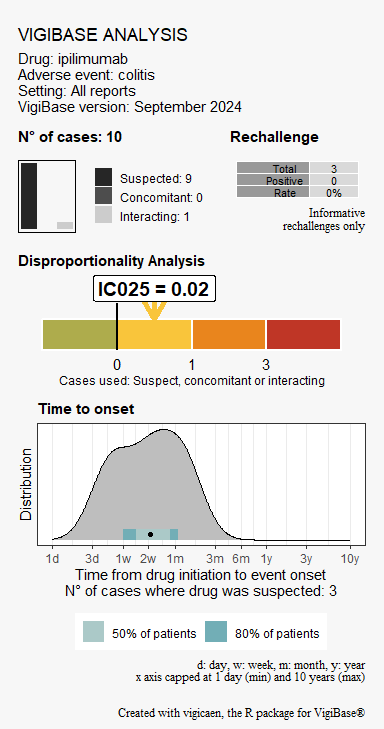

Lets take a look at the results. There are several sections.

## Add your own case time to onset

As we said earlier, we are working on a case reported by a physician. In this case, the colitis happened 150days after ipilimumab initiation.

We can add this information to the graph, using the `case_tto` argument.

```r
vigi_routine(
  case_tto  = 150,
  demo_data = demo,
  drug_data = drug,
  adr_data  = adr,
  link_data = link,
  d_code    = d_code,
  a_code    = a_code,
  vigibase_version = "September 2024"
)
```

[figure not shown]

## Customize the graph

There are a few options to customize the output of this graph.

You can use the `d_label` and `a_label` arguments to change the display in the legend.

## Exporting your results

You can save the results of `vigi_routine()` in a separate file, using the `export_to` argument.

`export_to` must be a character string, indicating the path on your computer where you want to file to be saved. It **must** end with one of the following extensions:

> “.eps”, “.ps”, “.tex” (pictex), “.pdf”, “.jpeg”, “.tiff”, “.png”, “.bmp”, “.svg” or “.wmf” (windows only)

Some of these extensions (like .svg) require additional packages to work. (e.g. svglite for “.svg”).

```r
vigi_routine(
  case_tto  = 150,
  demo_data = demo,
  drug_data = drug,
  adr_data  = adr,
  link_data = link,
  d_code    = d_code,
  a_code    = a_code,
  d_label   = "Ipilimumab",
  a_label   = "Colitis (HLT)",
  vigibase_version = "September 2024",
  export_to = "~/vigicaen_graph.png"
)
```

## Advanced options: suspect_only and d_code_2

### Example: Dual drug analysis

The example below is not very suitable: The idea is to use `d_code_2` when you want to study a fix drug combination, e.g. amoxicillin + clavulanic acid.

However, the syntax would be:

```r
d1 <- ex_$d_drecno["nivolumab"]
d2 <- ex_$d_drecno["ipilimumab"]
a_llt <- ex_$a_llt["a_colitis"]

demo <- demo_
adr  <- adr_
drug <- drug_
link <- link_

vigi_routine(
  demo_data = demo,
  drug_data = drug,
  adr_data  = adr,
  link_data = link,
  d_code = d1,
  d_code_2 = d2,
  a_code = a_llt,
  vigibase_version = "September 2024"
)
```

```
#> ℹ Dual drug analysis: only cases exposed to both 'nivolumab' and 'ipilimumab' are included.
```

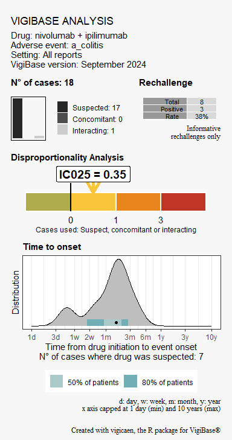

A CLI message will indicate that only cases exposed to both drugs are included in the analysis.